# Assessment I: Sports Analytics Jan Plan

## Section 1: Loading Packages and Data

##### 1. Load the tidyverse library

```r
library(tidyverse)
```

##### 2. Load the Olympic medals data into a data frame called olympics

```r
# the data is stored here: https://raw.githubusercontent.com/majerus/Sports_Analytics_Course/master/olympics.csv

olympics <- read_csv("https://raw.githubusercontent.com/majerus/Sports_Analytics_Course/master/olympics.csv")
```

Here’s some info about variables in the data:

- ID - Unique number for each athlete
- Name - Athlete’s name
- Sex - M or F
- Age - Integer
- Height - In centimeters
- Weight - In kilograms
- Team - Team name
- NOC - National Olympic Committee 3-letter code
- Games - Year and season
- Year - Integer
- Season - Summer or Winter
- City - Host city
- Sport - Sport
- Event - Event
- Medal - Gold, Silver, Bronze, or NA

## Section 2: Describing the data

##### 3. How many rows are in the data?

There are 39783 in the data.

##### 4. How many columns are in the data?

There are 15 in the data.

## Section 3: Country (NOC) Medal Counts

##### 5. Which country (NOC) has won the most medals?

```r
olympics %>%
  count(NOC) %>%
  arrange(desc(n)) %>%
  slice(1)
```

```
## # A tibble: 1 x 2
##   NOC       n
##   <chr> <int>
## 1 USA    5637
```

The USA has won the most medals.

##### 6. Which country has won the most medals in the winter games?

```r
olympics %>%
  filter(Season == "Winter") %>%
  count(NOC) %>%
  arrange(desc(n)) %>%
  slice(1)
```

```
## # A tibble: 1 x 2
##   NOC       n
##   <chr> <int>
## 1 USA     635
```

The USA has won the most medals in the Winter Olympics.

## Section 4: Sport Medal Counts

##### 7. Which sport has awarded the fewest medals?

```r
olympics %>%
  count(Sport) %>%
  arrange(n) %>%
  slice(1)
```

```
## # A tibble: 1 x 2
##   Sport           n
##   <chr>       <int>
## 1 Aeronautics     1
```

Aeronautics has awarded only a single medal.

##### 8. In how many Olympic Games were medals awarded in the sport of Tug-Of-War?

```r
olympics %>%
  filter(Sport == "Tug-Of-War") %>%
  distinct(Games) %>%
  nrow()
```

```
## [1] 6
```

Medals were awarded in Tug-Of-War in 6 Olympics.

## Section 5: BMI

##### 9. Which gold medal winner has the highest BMI? (BMI = kg/m^2)

```r
olympics %>%
  filter(Medal == "Gold") %>%
  mutate(height_meters = Height/100,
         height_meters_sq = height_meters^2,
         bmi = Weight/height_meters_sq) %>%
  arrange(desc(bmi)) %>%
  select(Name, Games, Sport, Weight, Height, bmi) %>%
  slice(1)
```

```
## # A tibble: 1 x 6
##   Name                       Games       Sport         Weight Height   bmi
##   <chr>                      <chr>       <chr>          <dbl>  <int> <dbl>
## 1 Andrey Ivanovich Chemerkin 1996 Summer Weightlifting    170    183  50.8
```

Andrey Ivanovich Chemerkin has the highest bmi of all gold medal winners. He won gold in weightlight during the 1996 summer games.

## Section 6: Graphing

##### 10. Create a box plot of the age of medal winners by sex

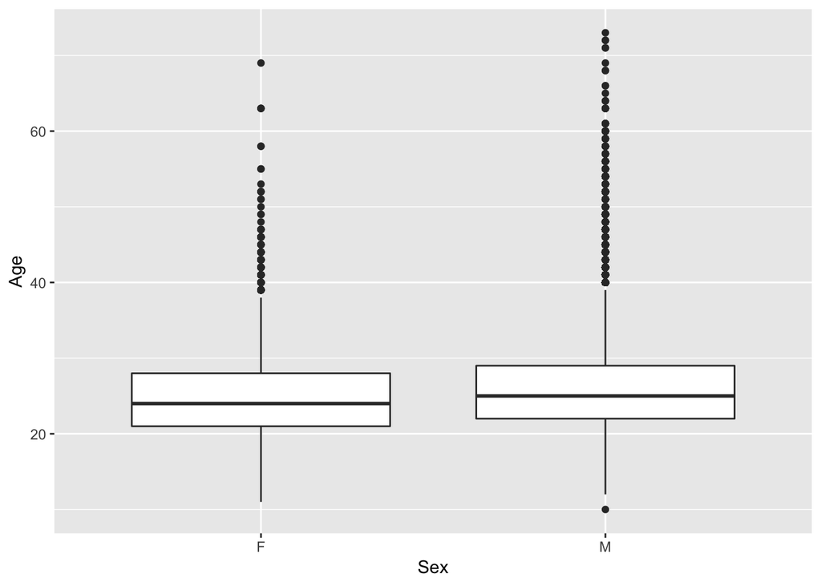

```r
olympics %>%
  ggplot(., aes(x = Sex, y = Age)) +
  geom_boxplot()
```

##### 11. Who is that person who won a medal when they were 10?

```r
olympics %>%
  filter(Age == 10) %>%
  select(Name, Age, NOC, Sport, Games, Medal)
```

```
## # A tibble: 1 x 6
##   Name                 Age NOC   Sport      Games       Medal
##   <chr>              <int> <chr> <chr>      <chr>       <chr>
## 1 Dimitrios Loundras    10 GRE   Gymnastics 1896 Summer Bronze
```

Dimitrios Loudras won a bronze medal in the 1896 Summer Olympics in gymnastics at the age of 10.

##### 12. Facet the boxplot by Medal

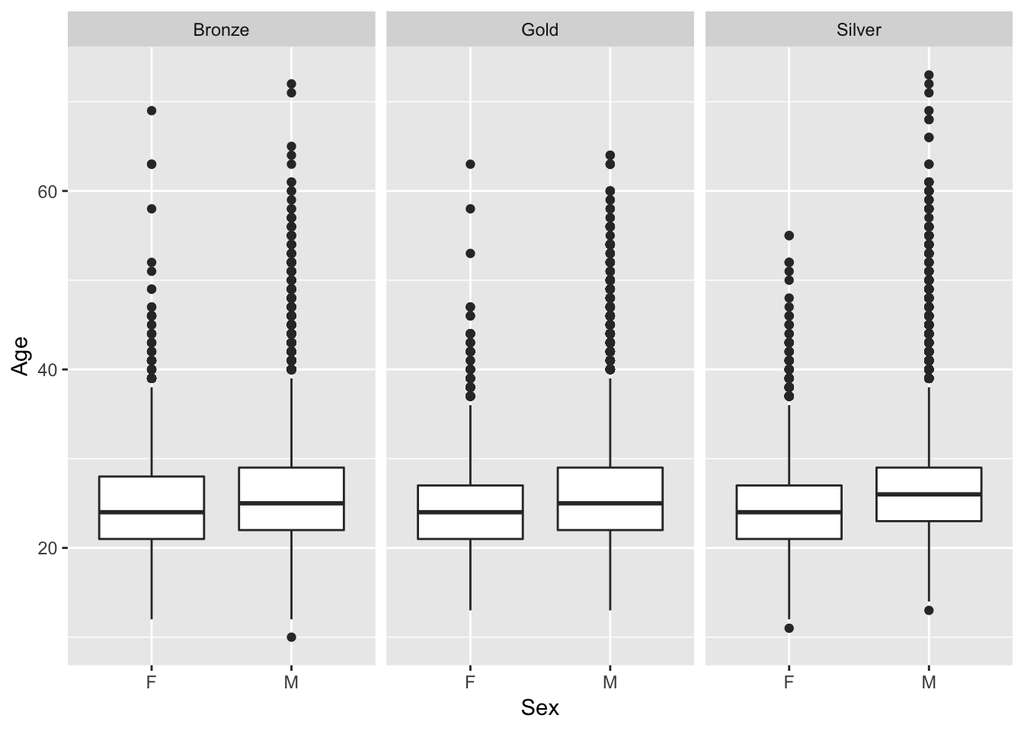

```r
olympics %>%
  ggplot(., aes(x = Sex, y = Age)) +
  geom_boxplot() +
  facet_wrap(~Medal)
```

## Section 7: Bonus

##### Which cities have hosted the games multiple times?

```r
olympics %>%
  select(City, Games) %>%
  distinct() %>%
  count(City) %>%
  filter(n > 1)
```

```
## # A tibble: 8 x 2
##   City             n
##   <chr>        <int>
## 1 Athina           3
## 2 Innsbruck        2
## 3 Lake Placid      2
## 4 London           3
## 5 Los Angeles      2
## 6 Paris            2
## 7 Sankt Moritz     2
## 8 Stockholm        2
```

Eight cities have hosted the Olympics more than once. There are Athina, Innsbruck, Lake Placid, London, Los Angeles, Paris, Sankt Moritz, and Stockholm.